# Testing for Association between Categorical Variables Using the Chi-squared Test

Paul M. Magwene

November 30, 2016

# Association Between Categorical Variables

A standard approach for testing the independence/dependence of a pair of categorical variables is to use a $\chi^2$ (Chi-squared) test of independence.

The null and alternative hypotheses for the $\chi^2$ test are as follows:

- $H_0$: the two categorical variables are independent
- $H_A$: the two categorical variables are dependent

# Contingency tables of observed counts

We typically depict the relationship between categorical variables using a “contingency table”.

|  | B1 | B2 | Total |
| --- | --- | --- | --- |
| A1 | $O_{11}$ | $O_{12}$ | $O_{11}$+$O_{12}$ |
| A2 | $O_{21}$ | $O_{22}$ | $O_{12}$+$O_{22}$ |
| Total | $O_{11}$+$O_{21}$ | $O_{12}$+$O_{22}$ | $O_{11}$+$O_{12}$+$O_{12}$+$O_{22}$ |

The rows and columns indicate the different categories for variables A and B respectively, and the cells, $O_{ij}$, give the counts of the number of observations for the corresponding combination of A and B. For example, the cell $O_{11}$ gives the number of observations that that belong to both the category A1 and B1, while $O_{12}$ gives the number that are both A1 and B2, etc.

# Example data set: Titanic passengers

Let’s revisit a data set we used when we discussed logistic regression that contains information about passengers on the Titanic.

titanic.csv includes information such as sex, age, passenger class (1st, 2nd, 3rd), and whether or not a passenger survived the sinking of the ship (0 = died, 1 = survived). We’ll use the this data set to illustrate the key steps of conducting a $\chi^2$ test.

## Constructing a contingency table in R

The R function `table` provides a simple way to construct contingency tables. Here’s how we can use it:

```r
titanic <- read.csv("https://github.com/pmagwene/Bio723/raw/master/datasets/titanic.csv")
table(titanic$sex, titanic$survived)
```

```
           0   1
  female 156 307
  male   708 142
```

`table` doesn’t produce the marginal counts. However we can easily add those by including a call to `addmargins`:

```r
addmargins(table(titanic$sex, titanic$survived))
```

```
            0    1  Sum
  female  156  307  463
  male    708  142  850
  Sum     864  449 1313
```

`xtabs` provides an alternate way to create a contingency table using a formula based interface.

```r
sex.by.survived <- xtabs(~ sex + survived, titanic)
sex.by.survived
```

```
        survived
sex        0   1
  female 156 307
  male   708 142
```

## Mosaic plots

A mosic plot is a useful way to visualize a contigency table.

```r
mosaicplot(sex.by.survived,
           color=c("steelblue","firebrick"),
           main="Sex x Survival, Titanic Passengers")
```

[output not shown]

# Expected counts

If the two categorical variables were independent than we would expect that the count in each cell of the contigency table to equal the product of the marginal probabilities times the total number of observations.

Here are the marginal probabilities for sex and survival in the Titanic data set:

```r
# marginal probabilities for rows of table (sex)
margin.table(sex.by.survived, margin = 1)/sum(sex.by.survived)

# marginal probabilities for cols of table (survived)
margin.table(sex.by.survived, margin = 2)/sum(sex.by.survived)
```

[output not shown]

## Calculating the expected counts

We can calculate the expected counts based the marginal probabilities as follows:

```r
observed.counts <- sex.by.survived

# get sum over rows and columns
total.ct <- sum(observed.counts)
total.ct

# get sums and probabilities over rows
row.sums <- margin.table(observed.counts, margin = 1)
row.probs <- row.sums/total.ct
row.sums

# get sum over columns
col.sums <- margin.table(observed.counts, margin = 2)
col.probs <- col.sums/total.ct
col.sums

# calculate expected probabilities
# the `outer` function gives the outer product -- all the pairwise multiples
# of the two vectors passed to it
expected.probs <- outer(row.probs, col.probs)
expected.probs

# and now calculate the expected counts
expected.counts <- expected.probs * total.ct
expected.counts
```

[output not shown]

```r
observed.counts
```

[output not shown]

# The $\chi^2$-statistic

To summarize the overall divergence between observed and expected values we’ll calculate a new test statistic, we’ll call $\chi^2$ (chi-squared), which is defined as:

$$\begin{align}
\chi^2 &= \frac{(O_{11} - E_{11})^2}{E_{11}} + \frac{(O_{12} - E_{12})^2}{E_{12}} + \cdots + \frac{(O_{mn} - E_{mn})^2}{E_{mn}} \\
\\
&= \sum_{i=1}^{m}\sum_{j=1}^{n} \frac{(O_{ij} - E_{ij})^2}{E_{ij}}
\end{align}$$

where $m$ and $n$ are the number of categories of the two variables under consideration.

We can think of the $\chi^2$-statistic as the sum of the normalized squared differences between observed and expected counts (where each cell is normalized by the expected counts).

Here’s the calculation of the $\chi^2$-statistic for the Titanic example:

```r
titanic.chisq <- sum((observed.counts - expected.counts)**2/expected.counts)
titanic.chisq
```

[output not shown]

# The $\chi^2$-distribution

Under the null hypothesis that the categorical variables are independent the $\chi^2$-statistic has a sampling distribution called the $\chi^2$-distribution. The $\chi^2$-distribution takes a single parameter, degree of freedom (df), which for the $\chi^2$ test of independence is equal to $(m-1)(n-1)$ where $m$ and $n$ are the number of categories in the two variables.

```r
library(ggplot2)
x <- seq(0, 8, length.out = 300)
d <- dchisq(x, df = 1)
qplot(x = x, y = d, geom="line",  color=I("steelblue"),
      xlab = "Chi2", ylab="Density")
```

[output not shown]

Here is a figuring demonstrating the $\chi^2$ distributions for different degrees of freedom:

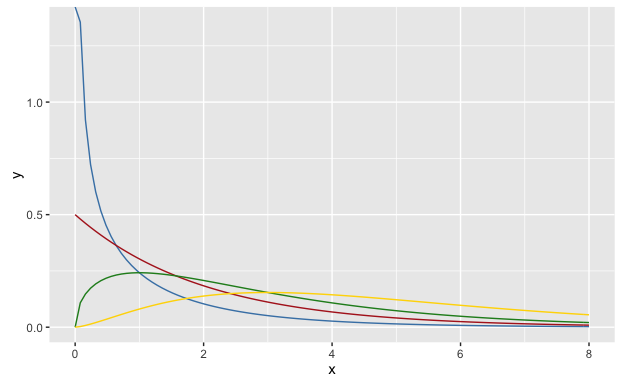

```r
ggplot(data.frame(x = c(0,8)), aes(x)) +
  stat_function(fun=dchisq, args=list(df = 1), color="steelblue") +
  stat_function(fun=dchisq, args=list(df = 2), color="firebrick") +
  stat_function(fun=dchisq, args=list(df = 3), color="forestgreen") +
  stat_function(fun=dchisq, args=list(df = 5), color="gold")
```

# Calculating a p-value

We can use `pchisq` to calculate the probability of observing a $\chi^2$ value at least as extreme as the one we observed under the null hypothesis of no association among the categorical variables:

```r
pchisq(titanic.chisq, df = 1, lower.tail = FALSE)
```

[output not shown]

# Simple $\chi^2$ tests in R

$\chi^2$ tests are a very common type of analysis. Therefore R has a built-in `chisq.test` function to make the calculations easy. Here’s how to use it:

```r
chi2.titanic <- chisq.test(titanic$sex, titanic$survived, correct = FALSE)

# summary overview, note rounding
chi2.titanic

# observed counts
chi2.titanic$observed

# expected counts
chi2.titanic$expected

# chi2 statistic
chi2.titanic$statistic

# corresponding p-value
chi2.titanic$p.value
```

[output not shown]

Note that I set `correct = FALSE`. This stops R from applying what is called “Yate’s Continuity Correction”, which is only appropriate when one or more of the counts are very small (<10).

Note too that the summary output from `chisq.test` rounds the $\chi^2$ statistic and the corresponding p-value, so if you want the exact values you need to get them explicitly.

# Your turn: Bumpus’ bird data

Bumpus (1898) described a sample of house sparrows which he collected after a very severe storm. The sample included 136 birds, sixty four of which perished during the storm. Also included in his description were a variety of morphological measurements on the birds and information about their sex and age (for male birds). This data set has become a benchmark in the evolutionary biology literature for demonstrating methods for analyzing natural selection. The bumpus data set is available from the class website as tab-delimited file called bumpus-data.txt .

Bumpus, H. C. 1898. The elimination of the unfit as illustrated by the introduced sparrow, Passer domesticus. (A fourth contribution to the study of variation.) Biol. Lectures: Woods Hole Marine Biological Laboratory, 209–225.

## Assignment (5 pts)

The variables “sex” and “survived” contain information on the sex of each bird, and whether they survived the storm. Carry out a $\chi^2$-test to test the hypothesis that there is a relationship between sex and survival. What is your conclusion based on this test? Show your work.